# Synthetic data for projection pursuit

Generating recoverable geometric structures hidden in high-dimensional data

## 1 Aim and motivation

This experiment embeds a clean nonlinear structure into a higher-dimensional dataset by rotating each signal coordinate with an independent Gaussian nuisance coordinate. We study whether the original pattern remains visible in the *observed coordinate pairs* as the rotation angle changes, how their Stringy05 values change, and whether the known inverse rotation recovers the initial pattern and its index value.

Four patterns are considered: **cubic, quartic, sine, and two moons**. Each dataset has `n = 500` observations and `p = 10` variables: four potentially signal-bearing mixed coordinates and six additional independent Gaussian nuisance variables. The initial static comparison uses **0°, 15°, 30°, and 45°**; a separate fine-angle comparison and later interactive slider expand this range. The same random seed is used within each pattern, so changing the angle does not change the underlying structure or nuisance draws.

## 2 Data generator and experimental settings

### 2.1 Data-generation mechanism

For the cubic, quartic, and sine examples, draw $t\sim N(0,1)$ and set the first signal coordinate to $t$. The second signal coordinate is, respectively, the third or fourth orthogonal-polynomial basis vector produced by R’s `poly()` function, or $\sin(\pi t)$. In particular, `poly(t, degree = 3)[, 3]` is *not* the same as the raw function $t^3$. For two moons, points are generated on two semicircular arcs.

Each signal coordinate is standardized using its **sample** mean and sample standard deviation:

$$\widetilde{s}_j = \frac{s_j-\overline{s}_j}{\operatorname{sd}(s_j)},
\qquad j=1,2.$$

Consequently, the two signal coordinates have sample SD exactly 1. Generate independent nuisance coordinates $n_1,n_2\sim N(0,1)$, which have population SD 1 (their realized sample SDs are approximately 1).

The signal and nuisance coordinates are mixed by an orthogonal rotation:

$$\begin{aligned}
x_1 &= \cos(\theta)s_1+\sin(\theta)n_1, &
x_3 &= -\sin(\theta)s_1+\cos(\theta)n_1,\\
x_2 &= \cos(\theta)s_2+\sin(\theta)n_2, &
x_4 &= -\sin(\theta)s_2+\cos(\theta)n_2.
\end{aligned}$$

For each signal–nuisance pair, the transformation matrix is

$$R(\theta)=\begin{bmatrix}\cos\theta & \sin\theta\\-\sin\theta & \cos\theta\end{bmatrix}.$$

It is **orthogonal** because $R(\theta)^\top R(\theta)=I$: its columns have unit length and are perpendicular ($\cos^2\theta+\sin^2\theta=1$). Hence its inverse is its transpose, and the original signal can be recovered from all four mixed variables.

Six additional nuisance variables $x_5,\ldots,x_{10}\sim N(0,1)$ are generated independently. With independent signal and nuisance coordinates, the rotated variables have approximately unit sample variance.

### 2.2 Reproducible setup

The QMD uses the exported generator from the `*bilbyr`.

```r
library(bilbyr)
library(tidyverse)
library(cassowaryr)
library(plotly)

n <- 500
p <- 10
seed <- 918
patterns <- c("cubic", "quartic", "sine", "two_moons")

# One common generator for static and interactive plots.
generate <- function(pattern, angle_deg) {
  bilbyr::gen_hidden_stringy(
    n = n, p = p, pattern = pattern,
    theta = angle_deg * pi / 180, seed = seed
  )
}

stringy05 <- function(x, y) {
  as.numeric(cassowaryr::sc_stringy05(x, y, rescale = TRUE))
}

recover_signal <- function(dat, angle_deg) {
  th <- angle_deg * pi / 180
  cbind(
    s1 = cos(th) * dat$x1 - sin(th) * dat$x3,
    s2 = cos(th) * dat$x2 - sin(th) * dat$x4
  )
}

# Main static experiment: 0, 15, 30, 45 degrees.
main_angles <- c(0, 15, 30, 45)
angles <- tibble(
  angle = main_angles * pi / 180,
  angle_label = factor(paste0(main_angles, "°"), levels = paste0(main_angles, "°"))
)

experiments <- tidyr::crossing(
  pattern = factor(patterns, levels = patterns), angles
) |>
  mutate(result = purrr::map2(as.character(pattern), angle, \(pat, th) {
    angle_deg <- th * 180 / pi
    x <- generate(pat, angle_deg)
    list(observed = x, original = as_tibble(recover_signal(x, angle_deg)))
  }))
```

## 3 Original clean geometric structures

The raw structural coordinates are standardized before rotation. The plots below therefore show the original clean patterns, without mixing with nuisance variables.

```r
original_patterns <- experiments |>
  filter(angle == 0) |>
  mutate(original = map(result, "original")) |>
  select(pattern, original) |>
  unnest(original)
```

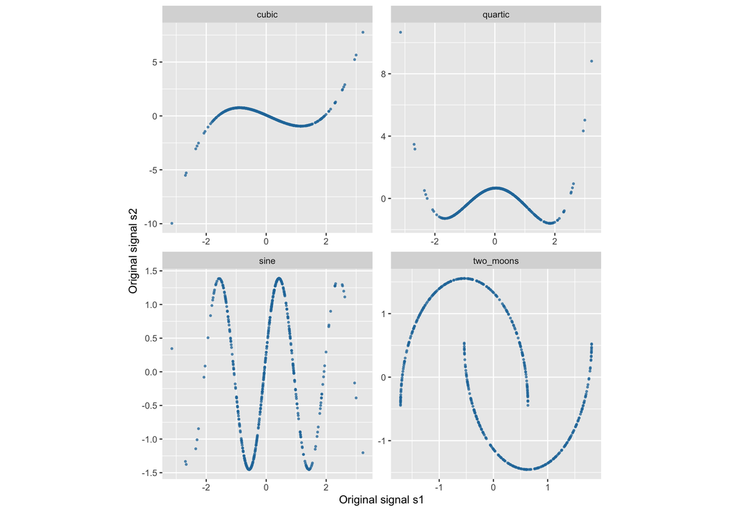

Figure 1: Original clean, standardized two-dimensional geometric patterns before rotation.

```r
ggplot(original_patterns, aes(s1, s2)) +
  geom_point(size = 0.65, alpha = 0.7, colour = "#2679A8") +
  facet_wrap(~ pattern, ncol = 2, scales = "free") +
  labs(x = "Original signal s1", y = "Original signal s2") +
  theme(aspect.ratio = 1)
```

## 4 Original and mixed views

The observed-coordinate views among the four mixed variables are all six combinations:

$$(x_1,x_2),\ (x_1,x_3),\ (x_1,x_4),\ (x_2,x_3),\ (x_2,x_4),\ (x_3,x_4).$$

```r
observed_pairs <- combn(paste0("x", 1:4), 2, simplify = FALSE)

make_views <- function(result, theta) {
  x <- result$observed
  original <- result$original

  mixed <- purrr::map_dfr(observed_pairs, function(vars) {
    tibble(
      u = x[[vars[1]]],
      v = x[[vars[2]]],
      view = paste(vars, collapse = "–"),
      type = "Mixed pair"
    )
  })

  bind_rows(
    tibble(
      u = original$s1,
      v = original$s2,
      view = "Original s1–s2",
      type = "Original"
    ),
    mixed
  )
}

view_data <- experiments |>
  mutate(views = map2(result, angle, make_views)) |>
  select(pattern, angle, angle_label, views) |>
  unnest(views) |>
  mutate(
    view = factor(
      view,
      levels = c(
        "Original s1–s2",
        vapply(
          observed_pairs,
          paste,
          character(1),
          collapse = "–"
        )
      )
    )
  )
```

### 4.1 Plot original and mixed views

Each figure shows one pattern, with rotation angles in rows and the original structure plus six mixed pairs in columns. **Note:** Each static facet uses its own axis scale (`scales = "free"`); use the interactive plots below for a fixed-scale visual comparison.

```
 Pattern: cubic
```

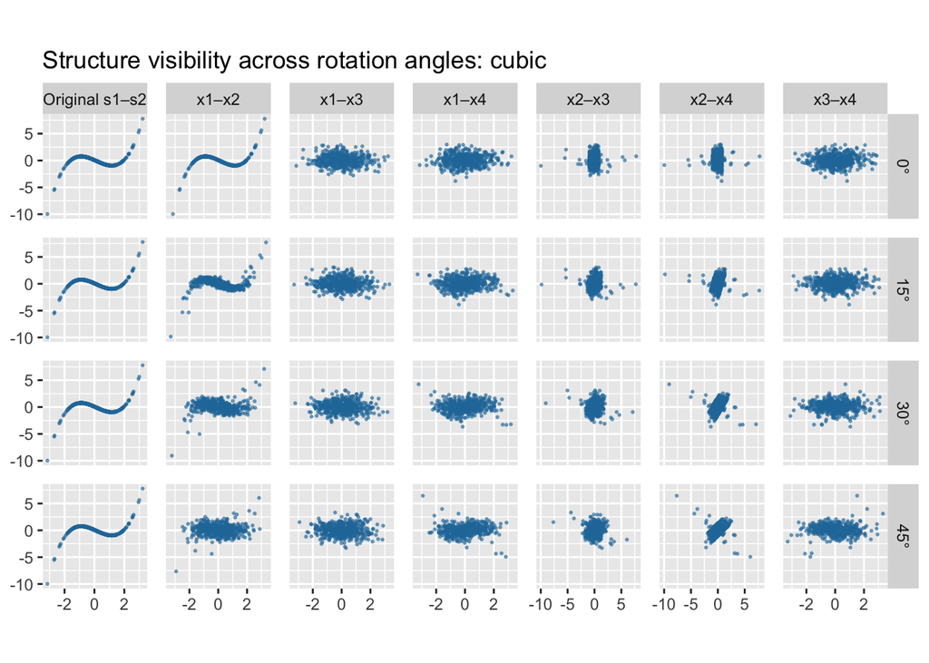

```
 Pattern: quartic
```

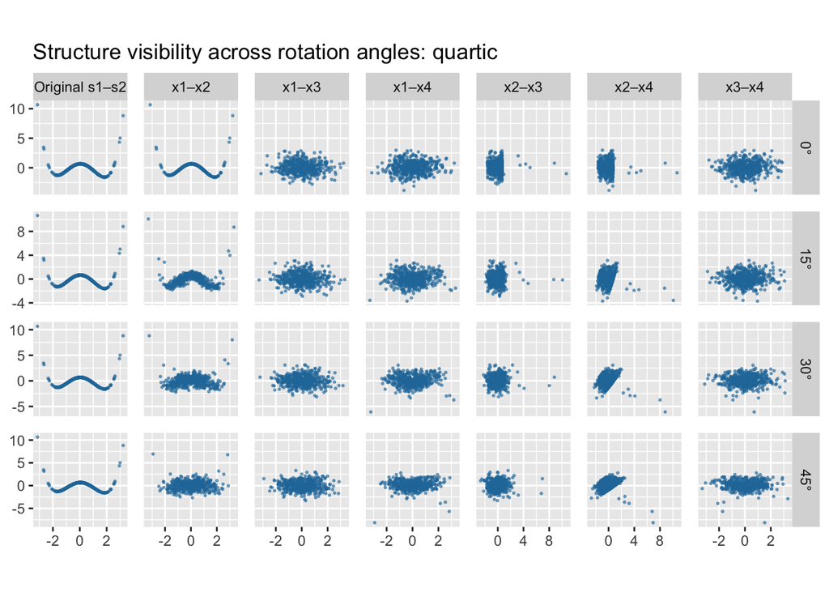

```
 Pattern: sine
```

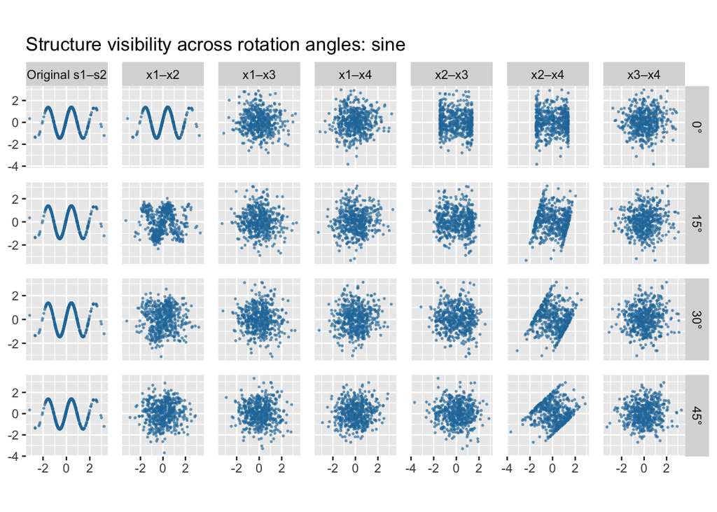

```
 Pattern: two_moons
```

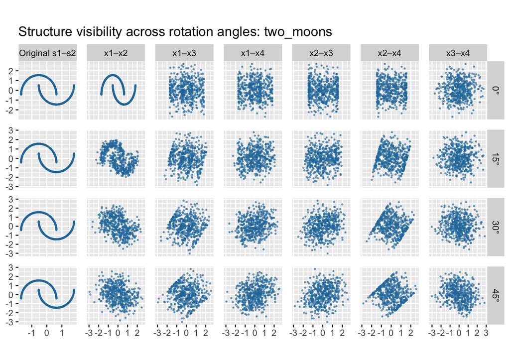

```r
#| label: fig-mixed-views
#| fig-cap: "Original structure and all six mixed coordinate pairs across rotation angles (one figure per pattern)."
#| fig-width: 17
#| fig-height: 10
#| results: asis

for (pat in patterns) {

  cat("\n\n Pattern: ", pat, "\n\n", sep = "")

  fig <- view_data |>
    filter(as.character(pattern) == pat) |>
    ggplot(aes(u, v)) +
    geom_point(
      size = 0.35,
      alpha = 0.55,
      colour = "#2679A8"
    ) +
    facet_grid(
      angle_label ~ view,
      scales = "free"
    ) +
    labs(
      title = paste(
        "Structure visibility across rotation angles:",
        pat
      )) +
    theme(aspect.ratio = 1,
          axis.title = element_blank(),
      panel.spacing = unit(0.7, "lines")
    )

  print(fig)
}
```

## 5 Calculate `Stringy05` index values

We calculate `Stringy05` for the original structure and each of the six mixed coordinate pairs.

```r
#| label: score-views
rescale_scores <- TRUE

score_stringy05 <- function(x, y, rescale = rescale_scores) {
  as.numeric(
    cassowaryr::sc_stringy05(
      x = x,
      y = y,
      rescale = rescale
    )
  )
}

index_scores <- view_data |>
  group_by(pattern, angle, angle_label, view, type) |>
  summarise(
    value = score_stringy05(u, v),
    .groups = "drop"
  )

stopifnot(all(is.finite(index_scores$value)))
```

### 5.1 Numerical scores for every view

```r
#| label: tbl-all-index-values
#| tbl-cap: "Rescaled Stringy05 values for original structures and all six mixed coordinate pairs across patterns and rotation angles."

index_scores |>
  select(pattern, angle_label, view, value) |>
  pivot_wider(
    names_from = view,
    values_from = value
  ) |>
  knitr::kable(digits = 4)
```

| pattern | angle_label | Original s1–s2 | x1–x2 | x1–x3 | x1–x4 | x2–x3 | x2–x4 | x3–x4 |
| --- | --- | --- | --- | --- | --- | --- | --- | --- |
| cubic | 0° | 1.0000 | 1.0000 | 0.0000 | 0.0000 | 0.2560 | 0.2813 | 0.0000 |
| cubic | 15° | 1.0000 | 0.3560 | 0.0000 | 0.0000 | 0.2186 | 0.1872 | 0.0000 |
| cubic | 30° | 1.0000 | 0.1421 | 0.0000 | 0.0000 | 0.0472 | 0.1731 | 0.0000 |
| cubic | 45° | 1.0000 | 0.0496 | 0.0000 | 0.0696 | 0.0285 | 0.0676 | 0.1111 |
| quartic | 0° | 1.0000 | 1.0000 | 0.0000 | 0.0000 | 0.1000 | 0.0940 | 0.0000 |
| quartic | 15° | 1.0000 | 0.2222 | 0.0000 | 0.0000 | 0.0709 | 0.1131 | 0.0314 |
| quartic | 30° | 1.0000 | 0.0590 | 0.0000 | 0.0000 | 0.0505 | 0.0797 | 0.0062 |
| quartic | 45° | 1.0000 | 0.0000 | 0.0000 | 0.0331 | 0.0182 | 0.2250 | 0.0299 |
| sine | 0° | 0.8747 | 0.8747 | 0.0000 | 0.0000 | 0.0336 | 0.0471 | 0.0000 |
| sine | 15° | 0.8747 | 0.0144 | 0.0000 | 0.0000 | 0.0000 | 0.0656 | 0.0000 |
| sine | 30° | 0.8747 | 0.0000 | 0.0000 | 0.0121 | 0.0702 | 0.0530 | 0.0000 |
| sine | 45° | 0.8747 | 0.0074 | 0.0000 | 0.0000 | 0.0000 | 0.0577 | 0.0000 |
| two_moons | 0° | 0.8364 | 0.8364 | 0.0192 | 0.0160 | 0.1199 | 0.0512 | 0.0000 |
| two_moons | 15° | 0.8364 | 0.1821 | 0.0192 | 0.0122 | 0.0000 | 0.0000 | 0.0000 |
| two_moons | 30° | 0.8364 | 0.0000 | 0.0105 | 0.0000 | 0.0000 | 0.0412 | 0.0000 |
| two_moons | 45° | 0.8364 | 0.0000 | 0.0109 | 0.0236 | 0.0000 | 0.0696 | 0.0000 |

Let’s investigate smaller rotation angles between 0° and 15° to determine how quickly Stringy05 decreases when the original structure is mixed with Gaussian nuisance variables.

```r
small_angles <- c(0, 1, 2, 3, 5, 7, 10, 12, 14)

experiments_small <- tidyr::crossing(
  pattern = patterns,
  angle = small_angles
) |>
  mutate(
    theta = angle * pi / 180,
    angle_label = factor(
      paste0(angle, "°"),
      levels = paste0(small_angles, "°")
    ),
    result = purrr::map2(
      pattern,
      theta,
      \(p, th) {

        x <- generate(p, th * 180 / pi)


        original <- tibble(
          s1 = cos(th) * x$x1 - sin(th) * x$x3,
          s2 = cos(th) * x$x2 - sin(th) * x$x4
        )

        list(
          observed = x,
          original = original
        )
      }
    )
  )

view_data_small <- experiments_small |>
  mutate(
    views = map2(result, angle, make_views)
  ) |>
  select(pattern, angle, angle_label, views) |>
  unnest(views) |>
  mutate(
    view = factor(
      view,
      levels = c(
        "Original s1–s2",
        vapply(
          observed_pairs,
          paste,
          character(1),
          collapse = "–"
        )
      )
    )
  )
```

### 5.2 Pattern: cubic

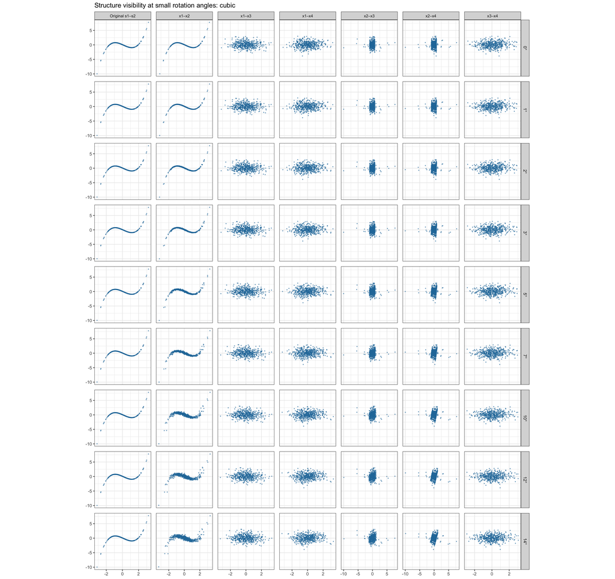

Figure 2

```r
plot_small_angles <- function(pat) {
  view_data_small |>
    filter(as.character(pattern) == pat) |>
    ggplot(aes(u, v)) +
    geom_point(
      size = 0.35,
      alpha = 0.55,
      colour = "#2679A8"
    ) +
    facet_grid(angle_label ~ view, scales = "free") +
    labs(title = paste("Structure visibility at small rotation angles:", pat)) +
    theme_bw() +
    theme(
      aspect.ratio = 1,
      axis.title = element_blank(),
      strip.text.x = element_text(size = 8),
      panel.spacing = unit(0.7, "lines")
    )
}

plot_small_angles("cubic")
```

### 5.3 Pattern: quartic

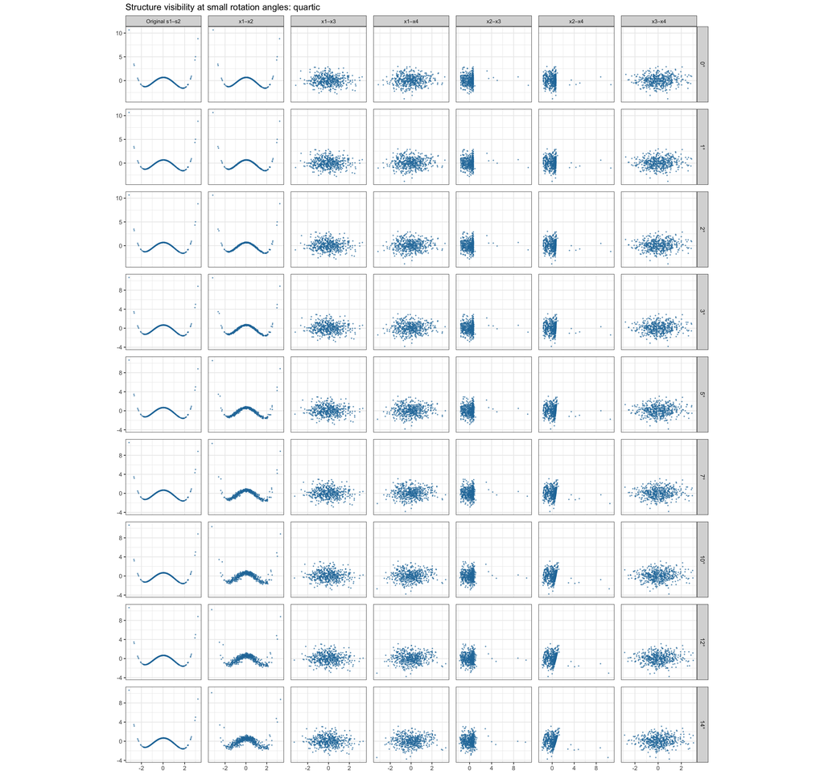

Figure 3

```r
plot_small_angles("quartic")
```

### 5.4 Pattern: sine

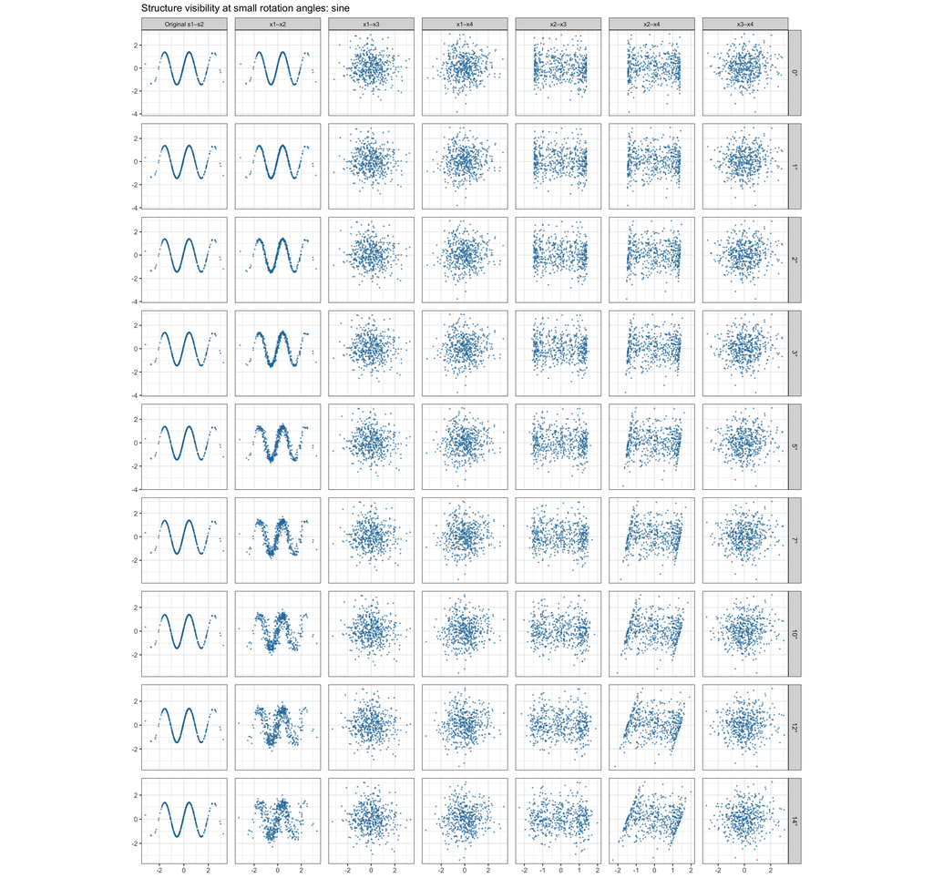

Figure 4

```r
plot_small_angles("sine")
```

### 5.5 Pattern: two moons

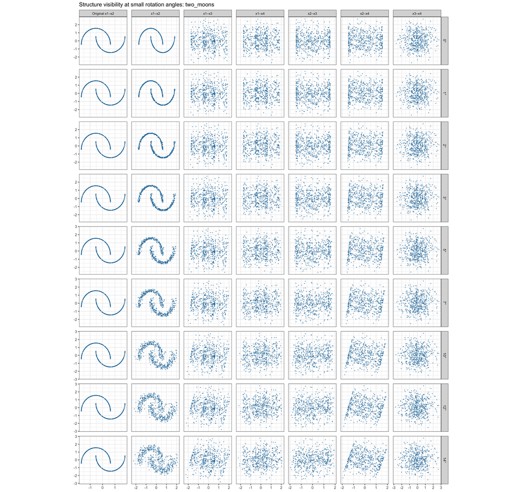

Figure 5

```r
plot_small_angles("two_moons")
```

```r
index_scores_small <- view_data_small |>
  group_by(pattern, angle, angle_label, view, type) |>
  summarise(
    value = score_stringy05(u, v),
    .groups = "drop"
  )
```

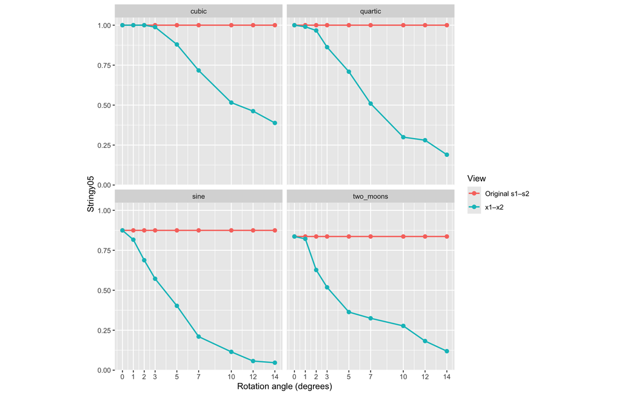

Figure 6: Change in rescaled Stringy05 for the original structure and x1–x2 as the rotation angle increases.

```r
index_scores_small |>
  filter(
    as.character(view) %in%
      c("Original s1–s2", "x1–x2")
  ) |>
  ggplot(
    aes(
      x = angle,
      y = value,
      colour = view,
      group = view
    )
  ) +
  geom_line(linewidth = 0.8) +
  geom_point(size = 2) +
  facet_wrap(~ pattern, ncol = 2) +
  scale_x_continuous(breaks = small_angles) +
  labs(
    x = "Rotation angle (degrees)",
    y = "Stringy05",
    colour = "View"
  ) +
  theme(aspect.ratio = 1)
```

## 6 Interactive comparison: original versus observed pair

Each plot is interactive: use the **angle slider / Play button** to compare the clean reference on the left with the fixed observed pair `(x1, x2)` on the right. Stringy05 values are written inside the plot and update with the slider.

```r
make_rotation_plot <- function(pattern) {
  datasets <- lapply(angles_deg, function(a) generate(pattern, a))
  original <- as.matrix(datasets[[1]][, c("x1", "x2")])
  original_score <- stringy05(original[, 1], original[, 2])


  max_abs <- max(abs(unlist(c(
    list(original),
    lapply(datasets, function(dat) as.matrix(dat[, c("x1", "x2")]))
  ))))
  lim <- 1.1 * max_abs
  offset <- 2.6 * lim
  keys <- sprintf("%02d°", angles_deg)

  points <- purrr::map2_dfr(datasets, seq_along(angles_deg), function(dat, j) {
    frame <- keys[j]
    dplyr::bind_rows(
      tibble::tibble(
        xx = original[, 1], yy = original[, 2],
        panel = "Original", frame = frame
      ),
      tibble::tibble(
        xx = dat$x1 + offset, yy = dat$x2,
        panel = "Observed", frame = frame
      )
    )
  })
  points$frame <- factor(points$frame, levels = keys)

  labels <- purrr::map2_dfr(datasets, seq_along(angles_deg), function(dat, j) {
    tibble::tibble(
      xx = c(0, offset),
      yy = c(-1.23 * lim, -1.23 * lim),
      label = c(
        sprintf("Original Stringy05 = %.3f", original_score),
        sprintf("Observed Stringy05 = %.3f", stringy05(dat$x1, dat$x2))
      ),
      frame = keys[j]
    )
  })
  labels$frame <- factor(labels$frame, levels = keys)

  fig <- plotly::plot_ly() |>
    plotly::add_trace(
      data = dplyr::filter(points, panel == "Original"),
      x = ~xx, y = ~yy, frame = ~frame,
      type = "scatter", mode = "markers",
      marker = list(size = 4, color = "#0D9488", opacity = 0.8),
      name = "Original signal", hoverinfo = "skip", inherit = FALSE
    ) |>
    plotly::add_trace(
      data = dplyr::filter(points, panel == "Observed"),
      x = ~xx, y = ~yy, frame = ~frame,
      type = "scatter", mode = "markers",
      marker = list(size = 4, color = "#2563EB", opacity = 0.8),
      name = "Observed (x1, x2)", hoverinfo = "skip", inherit = FALSE
    ) |>
    plotly::add_trace(
      data = labels, x = ~xx, y = ~yy, text = ~label, frame = ~frame,
      type = "scatter", mode = "text", showlegend = FALSE,
      textfont = list(size = 12, color = "#243047"),
      hoverinfo = "skip", inherit = FALSE
    ) |>
    plotly::layout(
      title = paste0("Pattern: ", pattern),
      xaxis = list(
        range = c(-1.22 * lim, offset + 1.22 * lim),
        showgrid = FALSE, zeroline = FALSE, showticklabels = FALSE,
        title = "", fixedrange = TRUE
      ),
      yaxis = list(
        range = c(-1.42 * lim, 1.25 * lim),
        showgrid = FALSE, zeroline = FALSE, showticklabels = FALSE,
        title = "", fixedrange = TRUE,
        scaleanchor = "x", scaleratio = 1
      ),
      annotations = list(
        list(x = 0, y = 1.04, xref = "x", yref = "paper",
             text = "Original (s1, s2)", showarrow = FALSE),
        list(x = offset, y = 1.04, xref = "x", yref = "paper",
             text = "Observed (x1, x2)", showarrow = FALSE)
      ),
      legend = list(orientation = "h", x = 0.1, y = 1.18),
      margin = list(l = 25, r = 25, b = 90, t = 105)
    ) |>
    plotly::animation_opts(frame = 350, transition = 0, redraw = FALSE) |>
    plotly::animation_slider(currentvalue = list(prefix = "Mixing angle θ = ")) |>
    plotly::animation_button(x = 1, xanchor = "right", y = 0)

  fig
}
```

### 6.1 Cubic

```r
make_rotation_plot("cubic")
```

[interactive chart not shown]

### 6.2 Quartic

```r
make_rotation_plot("quartic")
```

[interactive chart not shown]

### 6.3 Sine

```r
make_rotation_plot("sine")
```

[interactive chart not shown]

### 6.4 Two moons

```r
make_rotation_plot("two_moons")
```

[interactive chart not shown]

## 7 Comparing observed and recovered Stringy05 across the full angle range

The score of the observed pair `(x1, x2)` may change with the mixing angle, but the known recovery projection returns the clean pattern for each angle. The latter is a ground-truth reference, not a jellyfish optimization result.

```r
scores <- purrr::map_dfr(patterns, \(pat) {
  purrr::map_dfr(angles_deg, \(a) {
    dat <- generate(pat, a)
    recovered <- recover_signal(dat, a)
    tibble(
      pattern = pat,
      angle_deg = a,
      observed = stringy05(dat$x1, dat$x2),
      ground_truth = stringy05(recovered[, 1], recovered[, 2])
    )
  })
})
```

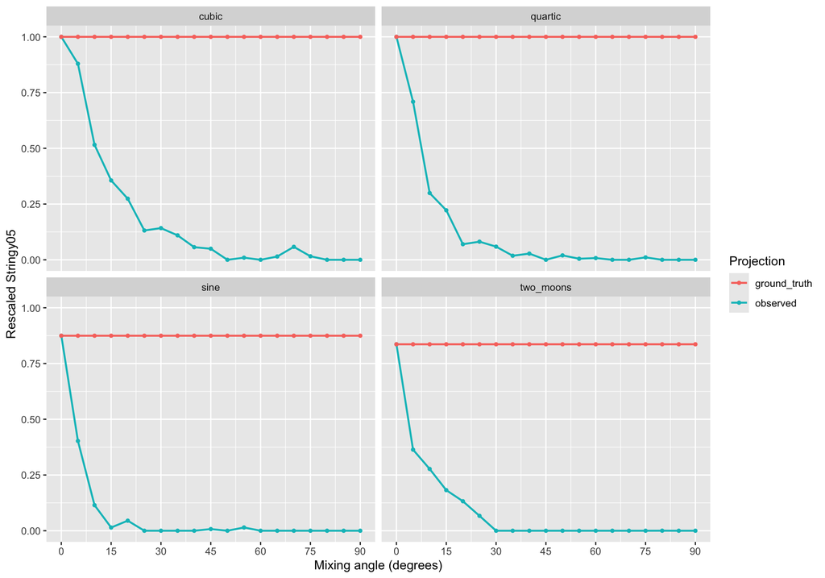

Figure 7

```r
scores |>
  pivot_longer(c(observed, ground_truth), names_to = "view", values_to = "value") |>
  ggplot(aes(angle_deg, value, colour = view)) +
  geom_line(linewidth = 0.8) +
  geom_point(size = 1.1) +
  facet_wrap(~pattern, ncol = 2) +
  scale_x_continuous(breaks = c(0, 15, 30, 45, 60, 75, 90)) +
  labs(x = "Mixing angle (degrees)", y = "Rescaled Stringy05", colour = "Projection")
```

```r
scores |>
  filter(angle_deg %in% c(0, 5, 15, 30, 45, 60, 90)) |>
  select(pattern, angle_deg, observed, ground_truth) |>
  knitr::kable(digits = 3)
```

Table 1: Observed and ground-truth Stringy05 at representative angles.

| pattern | angle_deg | observed | ground_truth |
| --- | --- | --- | --- |
| cubic | 0 | 1.000 | 1.000 |
| cubic | 5 | 0.879 | 1.000 |
| cubic | 15 | 0.356 | 1.000 |
| cubic | 30 | 0.142 | 1.000 |
| cubic | 45 | 0.050 | 1.000 |
| cubic | 60 | 0.000 | 1.000 |
| cubic | 90 | 0.000 | 1.000 |
| quartic | 0 | 1.000 | 1.000 |
| quartic | 5 | 0.709 | 1.000 |
| quartic | 15 | 0.222 | 1.000 |
| quartic | 30 | 0.059 | 1.000 |
| quartic | 45 | 0.000 | 1.000 |
| quartic | 60 | 0.008 | 1.000 |
| quartic | 90 | 0.000 | 1.000 |
| sine | 0 | 0.875 | 0.875 |
| sine | 5 | 0.403 | 0.875 |
| sine | 15 | 0.014 | 0.875 |
| sine | 30 | 0.000 | 0.875 |
| sine | 45 | 0.007 | 0.875 |
| sine | 60 | 0.000 | 0.875 |
| sine | 90 | 0.000 | 0.875 |
| two_moons | 0 | 0.836 | 0.836 |
| two_moons | 5 | 0.364 | 0.836 |
| two_moons | 15 | 0.182 | 0.836 |
| two_moons | 30 | 0.000 | 0.836 |
| two_moons | 45 | 0.000 | 0.836 |
| two_moons | 60 | 0.000 | 0.836 |
| two_moons | 90 | 0.000 | 0.836 |